# Risk Factor Analysis

## Outcome Variable

**Outcome Variable:** haz

## Predictor Variables

**Intervention Variable:** mbmi

**Adjustment Set:**

- arm
- W_mage
- meducyrs
- feducyrs
- hhwealth_quart
- W_nrooms
- W_nchldlt5
- brthmon
- W_parity
- impfloor
- impsan
- safeh20
- delta_W_mage
- delta_meducyrs
- delta_feducyrs
- delta_hhwealth_quart
- delta_W_nrooms
- delta_W_nchldlt5
- delta_brthmon
- delta_W_parity
- delta_impfloor
- delta_impsan
- delta_safeh20

## Stratifying Variables

The analysis was stratified on these variable(s):

- agecat
- studyid
- country

## Data Summary

| agecat | studyid | country | mbmi | n_cell | n |
| --- | --- | --- | --- | --- | --- |
| Birth | ki0047075b-MAL-ED | BANGLADESH | Normal weight | 194 | 222 |
| Birth | ki0047075b-MAL-ED | BANGLADESH | Underweight | 28 | 222 |
| Birth | ki0047075b-MAL-ED | BRAZIL | Normal weight | 59 | 64 |
| Birth | ki0047075b-MAL-ED | BRAZIL | Underweight | 5 | 64 |
| Birth | ki0047075b-MAL-ED | INDIA | Normal weight | 35 | 43 |
| Birth | ki0047075b-MAL-ED | INDIA | Underweight | 8 | 43 |
| Birth | ki0047075b-MAL-ED | NEPAL | Normal weight | 27 | 27 |
| Birth | ki0047075b-MAL-ED | NEPAL | Underweight | 0 | 27 |
| Birth | ki0047075b-MAL-ED | PERU | Normal weight | 221 | 226 |
| Birth | ki0047075b-MAL-ED | PERU | Underweight | 5 | 226 |
| Birth | ki0047075b-MAL-ED | SOUTH AFRICA | Normal weight | 98 | 101 |
| Birth | ki0047075b-MAL-ED | SOUTH AFRICA | Underweight | 3 | 101 |
| Birth | ki0047075b-MAL-ED | TANZANIA, UNITED REPUBLIC OF | Normal weight | 115 | 122 |
| Birth | ki0047075b-MAL-ED | TANZANIA, UNITED REPUBLIC OF | Underweight | 7 | 122 |
| Birth | ki1000304b-SAS-CompFeed | INDIA | Normal weight | 830 | 1135 |
| Birth | ki1000304b-SAS-CompFeed | INDIA | Underweight | 305 | 1135 |
| Birth | ki1017093-NIH-Birth | BANGLADESH | Normal weight | 506 | 608 |
| Birth | ki1017093-NIH-Birth | BANGLADESH | Underweight | 102 | 608 |
| Birth | ki1017093b-PROVIDE | BANGLADESH | Normal weight | 418 | 517 |
| Birth | ki1017093b-PROVIDE | BANGLADESH | Underweight | 99 | 517 |
| Birth | ki1017093c-NIH-Crypto | BANGLADESH | Normal weight | 663 | 729 |
| Birth | ki1017093c-NIH-Crypto | BANGLADESH | Underweight | 66 | 729 |
| Birth | ki1119695-PROBIT | BELARUS | Normal weight | 13200 | 13723 |
| Birth | ki1119695-PROBIT | BELARUS | Underweight | 523 | 13723 |
| Birth | ki1126311-ZVITAMBO | ZIMBABWE | Normal weight | 9162 | 9672 |
| Birth | ki1126311-ZVITAMBO | ZIMBABWE | Underweight | 510 | 9672 |
| Birth | kiGH5241-JiVitA-3 | BANGLADESH | Normal weight | 16381 | 26546 |
| Birth | kiGH5241-JiVitA-3 | BANGLADESH | Underweight | 10165 | 26546 |
| 6 months | ki0047075b-MAL-ED | BANGLADESH | Normal weight | 209 | 241 |
| 6 months | ki0047075b-MAL-ED | BANGLADESH | Underweight | 32 | 241 |

[output cut: 60 more lines]

The following strata were considered:

- agecat: 24 months, studyid: ki0047075b-MAL-ED, country: BANGLADESH
- agecat: 24 months, studyid: ki0047075b-MAL-ED, country: BRAZIL
- agecat: 24 months, studyid: ki0047075b-MAL-ED, country: INDIA
- agecat: 24 months, studyid: ki0047075b-MAL-ED, country: NEPAL
- agecat: 24 months, studyid: ki0047075b-MAL-ED, country: PERU
- agecat: 24 months, studyid: ki0047075b-MAL-ED, country: SOUTH AFRICA
- agecat: 24 months, studyid: ki0047075b-MAL-ED, country: TANZANIA, UNITED REPUBLIC OF
- agecat: 24 months, studyid: ki1017093-NIH-Birth, country: BANGLADESH
- agecat: 24 months, studyid: ki1017093b-PROVIDE, country: BANGLADESH
- agecat: 24 months, studyid: ki1017093c-NIH-Crypto, country: BANGLADESH
- agecat: 24 months, studyid: ki1066203-TanzaniaChild2, country: TANZANIA, UNITED REPUBLIC OF
- agecat: 24 months, studyid: ki1119695-PROBIT, country: BELARUS
- agecat: 24 months, studyid: ki1126311-ZVITAMBO, country: ZIMBABWE
- agecat: 24 months, studyid: ki1148112-LCNI-5, country: MALAWI
- agecat: 24 months, studyid: kiGH5241-JiVitA-3, country: BANGLADESH
- agecat: 6 months, studyid: ki0047075b-MAL-ED, country: BANGLADESH
- agecat: 6 months, studyid: ki0047075b-MAL-ED, country: BRAZIL
- agecat: 6 months, studyid: ki0047075b-MAL-ED, country: INDIA
- agecat: 6 months, studyid: ki0047075b-MAL-ED, country: NEPAL
- agecat: 6 months, studyid: ki0047075b-MAL-ED, country: PERU
- agecat: 6 months, studyid: ki0047075b-MAL-ED, country: SOUTH AFRICA
- agecat: 6 months, studyid: ki0047075b-MAL-ED, country: TANZANIA, UNITED REPUBLIC OF
- agecat: 6 months, studyid: ki1000304b-SAS-CompFeed, country: INDIA
- agecat: 6 months, studyid: ki1017093-NIH-Birth, country: BANGLADESH
- agecat: 6 months, studyid: ki1017093b-PROVIDE, country: BANGLADESH
- agecat: 6 months, studyid: ki1017093c-NIH-Crypto, country: BANGLADESH
- agecat: 6 months, studyid: ki1066203-TanzaniaChild2, country: TANZANIA, UNITED REPUBLIC OF
- agecat: 6 months, studyid: ki1119695-PROBIT, country: BELARUS
- agecat: 6 months, studyid: ki1126311-ZVITAMBO, country: ZIMBABWE
- agecat: 6 months, studyid: ki1148112-LCNI-5, country: MALAWI
- agecat: 6 months, studyid: kiGH5241-JiVitA-3, country: BANGLADESH
- agecat: Birth, studyid: ki0047075b-MAL-ED, country: BANGLADESH
- agecat: Birth, studyid: ki0047075b-MAL-ED, country: BRAZIL
- agecat: Birth, studyid: ki0047075b-MAL-ED, country: INDIA
- agecat: Birth, studyid: ki0047075b-MAL-ED, country: NEPAL
- agecat: Birth, studyid: ki0047075b-MAL-ED, country: PERU
- agecat: Birth, studyid: ki0047075b-MAL-ED, country: SOUTH AFRICA
- agecat: Birth, studyid: ki0047075b-MAL-ED, country: TANZANIA, UNITED REPUBLIC OF
- agecat: Birth, studyid: ki1000304b-SAS-CompFeed, country: INDIA
- agecat: Birth, studyid: ki1017093-NIH-Birth, country: BANGLADESH
- agecat: Birth, studyid: ki1017093b-PROVIDE, country: BANGLADESH
- agecat: Birth, studyid: ki1017093c-NIH-Crypto, country: BANGLADESH
- agecat: Birth, studyid: ki1119695-PROBIT, country: BELARUS
- agecat: Birth, studyid: ki1126311-ZVITAMBO, country: ZIMBABWE
- agecat: Birth, studyid: kiGH5241-JiVitA-3, country: BANGLADESH

### Dropped Strata

Some strata were dropped due to rare outcomes:

- agecat: Birth, studyid: ki0047075b-MAL-ED, country: NEPAL
- agecat: Birth, studyid: ki0047075b-MAL-ED, country: SOUTH AFRICA
- agecat: 6 months, studyid: ki0047075b-MAL-ED, country: NEPAL
- agecat: 24 months, studyid: ki0047075b-MAL-ED, country: NEPAL
- agecat: 24 months, studyid: ki0047075b-MAL-ED, country: PERU
- agecat: 24 months, studyid: ki1066203-TanzaniaChild2, country: TANZANIA, UNITED REPUBLIC OF

## Methods Detail

We’re interested in the causal parameters $E[Y_a]$ for all values of $a \in \mathcal{A}$. These parameters represent the mean outcome if, possibly contrary to fact, we intervened to set all units to have $A=a$. Under the randomization and positivity assumptions, these are identified by the statistical parameters $\psi_a=E_W[E_{Y|A,W}(Y|A=a,W)]$. In addition, we’re interested in the mean of $Y$, $E[Y]$ under no intervention (the observed mean). We will estimate these parameters by using SuperLearner to fit the relevant likelihood factors – $E_{Y|A,W}(Y|A=a,W)$ and $p(A=a|W)$, and then updating our likelihood fit using a joint TMLE.

For unadjusted analyses ($W=\{\}$), initial likelihoods were estimated using Lrnr_glm to estimate the simple $E(Y|A)$ and Lrnr_mean to estimate $p(A)$. For adjusted analyses, a small library containing Lrnr_glmnet, Lrnr_xgboost, and Lrnr_mean was used.

Having estimated these parameters, we will then use the delta method to estimate relative risks and attributable risks relative to a prespecified baseline level of $A$.

# Results Detail

## Results Plots

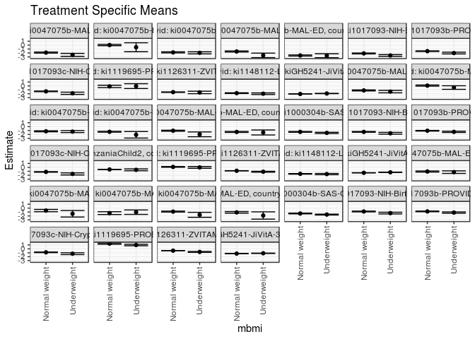

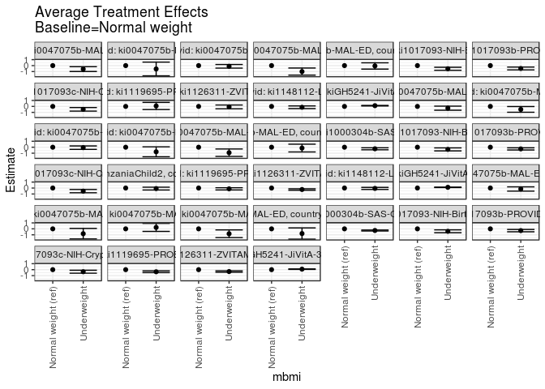

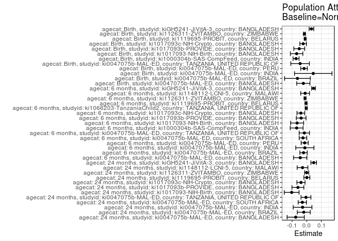

## Results Table

### Parameter: TSM

| agecat | studyid | country | intervention_level | baseline_level | estimate | ci_lower | ci_upper |
| --- | --- | --- | --- | --- | --- | --- | --- |
| Birth | ki0047075b-MAL-ED | BANGLADESH | Normal weight | NA | -1.0548210 | -1.2016903 | -0.9079518 |
| Birth | ki0047075b-MAL-ED | BANGLADESH | Underweight | NA | -1.2139499 | -1.5420983 | -0.8858015 |
| Birth | ki0047075b-MAL-ED | BRAZIL | Normal weight | NA | -0.6249153 | -0.9137560 | -0.3360745 |
| Birth | ki0047075b-MAL-ED | BRAZIL | Underweight | NA | -1.4380000 | -2.2732876 | -0.6027124 |
| Birth | ki0047075b-MAL-ED | INDIA | Normal weight | NA | -1.2745714 | -1.6299983 | -0.9191446 |
| Birth | ki0047075b-MAL-ED | INDIA | Underweight | NA | -1.0362500 | -1.6020040 | -0.4704960 |
| Birth | ki0047075b-MAL-ED | PERU | Normal weight | NA | -0.8869683 | -1.0065725 | -0.7673641 |
| Birth | ki0047075b-MAL-ED | PERU | Underweight | NA | -1.7080000 | -2.3409322 | -1.0750678 |
| Birth | ki0047075b-MAL-ED | TANZANIA, UNITED REPUBLIC OF | Normal weight | NA | -1.0913043 | -1.3056634 | -0.8769453 |
| Birth | ki0047075b-MAL-ED | TANZANIA, UNITED REPUBLIC OF | Underweight | NA | -1.8785714 | -2.8008825 | -0.9562603 |
| Birth | ki1000304b-SAS-CompFeed | INDIA | Normal weight | NA | -1.3709989 | -1.4640712 | -1.2779266 |
| Birth | ki1000304b-SAS-CompFeed | INDIA | Underweight | NA | -1.6461229 | -1.7561055 | -1.5361403 |
| Birth | ki1017093-NIH-Birth | BANGLADESH | Normal weight | NA | -0.8622510 | -0.9581961 | -0.7663060 |
| Birth | ki1017093-NIH-Birth | BANGLADESH | Underweight | NA | -1.2761330 | -1.4973684 | -1.0548976 |
| Birth | ki1017093b-PROVIDE | BANGLADESH | Normal weight | NA | -0.8414490 | -0.9264833 | -0.7564147 |
| Birth | ki1017093b-PROVIDE | BANGLADESH | Underweight | NA | -1.1390367 | -1.3148744 | -0.9631989 |
| Birth | ki1017093c-NIH-Crypto | BANGLADESH | Normal weight | NA | -0.8845803 | -0.9614151 | -0.8077456 |
| Birth | ki1017093c-NIH-Crypto | BANGLADESH | Underweight | NA | -1.2304974 | -1.4636811 | -0.9973138 |
| Birth | ki1119695-PROBIT | BELARUS | Normal weight | NA | 1.3379230 | 1.1782239 | 1.4976221 |
| Birth | ki1119695-PROBIT | BELARUS | Underweight | NA | 0.9842869 | 0.7992650 | 1.1693088 |
| Birth | ki1126311-ZVITAMBO | ZIMBABWE | Normal weight | NA | -0.4606155 | -0.4856868 | -0.4355442 |
| Birth | ki1126311-ZVITAMBO | ZIMBABWE | Underweight | NA | -0.7781683 | -0.8969527 | -0.6593839 |
| Birth | kiGH5241-JiVitA-3 | BANGLADESH | Normal weight | NA | -1.2047445 | -1.2368873 | -1.1726017 |
| Birth | kiGH5241-JiVitA-3 | BANGLADESH | Underweight | NA | -1.1204879 | -1.1588558 | -1.0821199 |
| 6 months | ki0047075b-MAL-ED | BANGLADESH | Normal weight | NA | -1.1613156 | -1.2878181 | -1.0348131 |
| 6 months | ki0047075b-MAL-ED | BANGLADESH | Underweight | NA | -1.4583078 | -1.7747449 | -1.1418707 |
| 6 months | ki0047075b-MAL-ED | BRAZIL | Normal weight | NA | 0.0748995 | -0.0742030 | 0.2240020 |
| 6 months | ki0047075b-MAL-ED | BRAZIL | Underweight | NA | -0.4262963 | -0.8810079 | 0.0284153 |
| 6 months | ki0047075b-MAL-ED | INDIA | Normal weight | NA | -1.1929840 | -1.3264375 | -1.0595305 |
| 6 months | ki0047075b-MAL-ED | INDIA | Underweight | NA | -1.2630631 | -1.5164280 | -1.0096982 |
| 6 months | ki0047075b-MAL-ED | PERU | Normal weight | NA | -1.3144382 | -1.4230912 | -1.2057852 |
| 6 months | ki0047075b-MAL-ED | PERU | Underweight | NA | -2.0820000 | -2.9100519 | -1.2539481 |
| 6 months | ki0047075b-MAL-ED | SOUTH AFRICA | Normal weight | NA | -1.0475413 | -1.1785458 | -0.9165369 |
| 6 months | ki0047075b-MAL-ED | SOUTH AFRICA | Underweight | NA | -1.9657143 | -2.5717876 | -1.3596410 |
| 6 months | ki0047075b-MAL-ED | TANZANIA, UNITED REPUBLIC OF | Normal weight | NA | -1.3523716 | -1.4763722 | -1.2283711 |
| 6 months | ki0047075b-MAL-ED | TANZANIA, UNITED REPUBLIC OF | Underweight | NA | -1.4926604 | -2.1334583 | -0.8518626 |
| 6 months | ki1000304b-SAS-CompFeed | INDIA | Normal weight | NA | -1.3382133 | -1.4388103 | -1.2376163 |
| 6 months | ki1000304b-SAS-CompFeed | INDIA | Underweight | NA | -1.6009100 | -1.7552407 | -1.4465793 |
| 6 months | ki1017093-NIH-Birth | BANGLADESH | Normal weight | NA | -1.3416743 | -1.4373406 | -1.2460080 |
| 6 months | ki1017093-NIH-Birth | BANGLADESH | Underweight | NA | -1.7071382 | -1.9399370 | -1.4743394 |
| 6 months | ki1017093b-PROVIDE | BANGLADESH | Normal weight | NA | -1.0515729 | -1.1351441 | -0.9680016 |
| 6 months | ki1017093b-PROVIDE | BANGLADESH | Underweight | NA | -1.3330039 | -1.4927811 | -1.1732267 |
| 6 months | ki1017093c-NIH-Crypto | BANGLADESH | Normal weight | NA | -1.1586263 | -1.2330096 | -1.0842431 |
| 6 months | ki1017093c-NIH-Crypto | BANGLADESH | Underweight | NA | -1.6716489 | -1.9362502 | -1.4070477 |
| 6 months | ki1066203-TanzaniaChild2 | TANZANIA, UNITED REPUBLIC OF | Normal weight | NA | -0.5368395 | -0.5872733 | -0.4864057 |
| 6 months | ki1066203-TanzaniaChild2 | TANZANIA, UNITED REPUBLIC OF | Underweight | NA | -0.6291722 | -0.8580343 | -0.4003101 |
| 6 months | ki1119695-PROBIT | BELARUS | Normal weight | NA | 0.1201547 | 0.0275991 | 0.2127102 |
| 6 months | ki1119695-PROBIT | BELARUS | Underweight | NA | -0.0133879 | -0.2400827 | 0.2133070 |
| 6 months | ki1126311-ZVITAMBO | ZIMBABWE | Normal weight | NA | -0.8685602 | -0.8967526 | -0.8403677 |
| 6 months | ki1126311-ZVITAMBO | ZIMBABWE | Underweight | NA | -1.1146826 | -1.2356679 | -0.9936972 |
| 6 months | ki1148112-LCNI-5 | MALAWI | Normal weight | NA | -1.6467752 | -1.7251160 | -1.5684344 |
| 6 months | ki1148112-LCNI-5 | MALAWI | Underweight | NA | -1.7101293 | -1.8670003 | -1.5532583 |
| 6 months | kiGH5241-JiVitA-3 | BANGLADESH | Normal weight | NA | -1.3826889 | -1.4095138 | -1.3558640 |
| 6 months | kiGH5241-JiVitA-3 | BANGLADESH | Underweight | NA | -1.2627546 | -1.2934010 | -1.2321082 |
| 24 months | ki0047075b-MAL-ED | BANGLADESH | Normal weight | NA | -1.9037771 | -2.0353575 | -1.7721967 |
| 24 months | ki0047075b-MAL-ED | BANGLADESH | Underweight | NA | -2.4887552 | -2.8667184 | -2.1107919 |
| 24 months | ki0047075b-MAL-ED | BRAZIL | Normal weight | NA | 0.0271296 | -0.1429190 | 0.1971783 |
| 24 months | ki0047075b-MAL-ED | BRAZIL | Underweight | NA | -0.5391667 | -1.6773310 | 0.5989977 |
| 24 months | ki0047075b-MAL-ED | INDIA | Normal weight | NA | -1.8549644 | -1.9965080 | -1.7134207 |
| 24 months | ki0047075b-MAL-ED | INDIA | Underweight | NA | -1.9703422 | -2.2389905 | -1.7016939 |
| 24 months | ki0047075b-MAL-ED | SOUTH AFRICA | Normal weight | NA | -1.6174449 | -1.7555025 | -1.4793874 |
| 24 months | ki0047075b-MAL-ED | SOUTH AFRICA | Underweight | NA | -2.6192857 | -3.1998173 | -2.0387542 |
| 24 months | ki0047075b-MAL-ED | TANZANIA, UNITED REPUBLIC OF | Normal weight | NA | -2.6398526 | -2.7782268 | -2.5014784 |
| 24 months | ki0047075b-MAL-ED | TANZANIA, UNITED REPUBLIC OF | Underweight | NA | -2.7000470 | -3.2082543 | -2.1918396 |
| 24 months | ki1017093-NIH-Birth | BANGLADESH | Normal weight | NA | -2.1164475 | -2.2296638 | -2.0032311 |
| 24 months | ki1017093-NIH-Birth | BANGLADESH | Underweight | NA | -2.6453155 | -2.8690065 | -2.4216244 |
| 24 months | ki1017093b-PROVIDE | BANGLADESH | Normal weight | NA | -1.5401312 | -1.6303373 | -1.4499251 |
| 24 months | ki1017093b-PROVIDE | BANGLADESH | Underweight | NA | -2.0239159 | -2.2435621 | -1.8042698 |
| 24 months | ki1017093c-NIH-Crypto | BANGLADESH | Normal weight | NA | -1.4020916 | -1.4888996 | -1.3152836 |
| 24 months | ki1017093c-NIH-Crypto | BANGLADESH | Underweight | NA | -1.8916011 | -2.1770038 | -1.6061985 |
| 24 months | ki1119695-PROBIT | BELARUS | Normal weight | NA | -0.1331187 | -0.4368164 | 0.1705789 |
| 24 months | ki1119695-PROBIT | BELARUS | Underweight | NA | -0.0575653 | -0.6703325 | 0.5552019 |
| 24 months | ki1126311-ZVITAMBO | ZIMBABWE | Normal weight | NA | -1.5978030 | -1.6613646 | -1.5342414 |
| 24 months | ki1126311-ZVITAMBO | ZIMBABWE | Underweight | NA | -1.6775288 | -1.9876129 | -1.3674447 |
| 24 months | ki1148112-LCNI-5 | MALAWI | Normal weight | NA | -1.8564217 | -1.9458019 | -1.7670415 |
| 24 months | ki1148112-LCNI-5 | MALAWI | Underweight | NA | -1.9970118 | -2.2031122 | -1.7909114 |
| 24 months | kiGH5241-JiVitA-3 | BANGLADESH | Normal weight | NA | -2.0671481 | -2.1010659 | -2.0332303 |
| 24 months | kiGH5241-JiVitA-3 | BANGLADESH | Underweight | NA | -1.9442671 | -1.9845003 | -1.9040338 |

### Parameter: E(Y)

| agecat | studyid | country | intervention_level | baseline_level | estimate | ci_lower | ci_upper |
| --- | --- | --- | --- | --- | --- | --- | --- |
| Birth | ki0047075b-MAL-ED | BANGLADESH | NA | NA | -1.0778829 | -1.2122580 | -0.9435077 |
| Birth | ki0047075b-MAL-ED | BRAZIL | NA | NA | -0.6884375 | -0.9678371 | -0.4090379 |
| Birth | ki0047075b-MAL-ED | INDIA | NA | NA | -1.2302326 | -1.5393614 | -0.9211037 |
| Birth | ki0047075b-MAL-ED | PERU | NA | NA | -0.9051327 | -1.0238686 | -0.7863969 |
| Birth | ki0047075b-MAL-ED | TANZANIA, UNITED REPUBLIC OF | NA | NA | -1.1364754 | -1.3478823 | -0.9250686 |
| Birth | ki1000304b-SAS-CompFeed | INDIA | NA | NA | -1.4438150 | -1.5337502 | -1.3538797 |
| Birth | ki1017093-NIH-Birth | BANGLADESH | NA | NA | -0.9310197 | -1.0197391 | -0.8423003 |
| Birth | ki1017093b-PROVIDE | BANGLADESH | NA | NA | -0.8925145 | -0.9687201 | -0.8163089 |
| Birth | ki1017093c-NIH-Crypto | BANGLADESH | NA | NA | -0.9089163 | -0.9806324 | -0.8372002 |
| Birth | ki1119695-PROBIT | BELARUS | NA | NA | 1.3271449 | 1.1680455 | 1.4862444 |
| Birth | ki1126311-ZVITAMBO | ZIMBABWE | NA | NA | -0.4764413 | -0.5009156 | -0.4519670 |
| Birth | kiGH5241-JiVitA-3 | BANGLADESH | NA | NA | -1.1727085 | -1.2008532 | -1.1445639 |
| 6 months | ki0047075b-MAL-ED | BANGLADESH | NA | NA | -1.2054910 | -1.3228953 | -1.0880867 |
| 6 months | ki0047075b-MAL-ED | BRAZIL | NA | NA | 0.0532131 | -0.0914567 | 0.1978830 |
| 6 months | ki0047075b-MAL-ED | INDIA | NA | NA | -1.2058014 | -1.3242792 | -1.0873236 |
| 6 months | ki0047075b-MAL-ED | PERU | NA | NA | -1.3285478 | -1.4371840 | -1.2199116 |
| 6 months | ki0047075b-MAL-ED | SOUTH AFRICA | NA | NA | -1.0733534 | -1.2031913 | -0.9435155 |
| 6 months | ki0047075b-MAL-ED | TANZANIA, UNITED REPUBLIC OF | NA | NA | -1.3687449 | -1.4907629 | -1.2467270 |
| 6 months | ki1000304b-SAS-CompFeed | INDIA | NA | NA | -1.4068893 | -1.4981242 | -1.3156543 |
| 6 months | ki1017093-NIH-Birth | BANGLADESH | NA | NA | -1.4073821 | -1.4960598 | -1.3187043 |
| 6 months | ki1017093b-PROVIDE | BANGLADESH | NA | NA | -1.0895301 | -1.1639589 | -1.0151013 |
| 6 months | ki1017093c-NIH-Crypto | BANGLADESH | NA | NA | -1.1986783 | -1.2700937 | -1.1272630 |
| 6 months | ki1066203-TanzaniaChild2 | TANZANIA, UNITED REPUBLIC OF | NA | NA | -0.5405711 | -0.5899965 | -0.4911457 |
| 6 months | ki1119695-PROBIT | BELARUS | NA | NA | 0.1153731 | 0.0222128 | 0.2085334 |
| 6 months | ki1126311-ZVITAMBO | ZIMBABWE | NA | NA | -0.8800508 | -0.9074511 | -0.8526506 |
| 6 months | ki1148112-LCNI-5 | MALAWI | NA | NA | -1.6577751 | -1.7275296 | -1.5880207 |
| 6 months | kiGH5241-JiVitA-3 | BANGLADESH | NA | NA | -1.3365058 | -1.3595555 | -1.3134561 |
| 24 months | ki0047075b-MAL-ED | BANGLADESH | NA | NA | -1.9789151 | -2.1055330 | -1.8522972 |
| 24 months | ki0047075b-MAL-ED | BRAZIL | NA | NA | 0.0069048 | -0.1627841 | 0.1765936 |
| 24 months | ki0047075b-MAL-ED | INDIA | NA | NA | -1.8831195 | -2.0084753 | -1.7577636 |
| 24 months | ki0047075b-MAL-ED | SOUTH AFRICA | NA | NA | -1.6474145 | -1.7842298 | -1.5105993 |
| 24 months | ki0047075b-MAL-ED | TANZANIA, UNITED REPUBLIC OF | NA | NA | -2.6451636 | -2.7802323 | -2.5100948 |
| 24 months | ki1017093-NIH-Birth | BANGLADESH | NA | NA | -2.2190579 | -2.3217459 | -2.1163699 |
| 24 months | ki1017093b-PROVIDE | BANGLADESH | NA | NA | -1.6002600 | -1.6836163 | -1.5169036 |
| 24 months | ki1017093c-NIH-Crypto | BANGLADESH | NA | NA | -1.4412646 | -1.5249156 | -1.3576135 |
| 24 months | ki1119695-PROBIT | BELARUS | NA | NA | -0.1322181 | -0.4300523 | 0.1656161 |
| 24 months | ki1126311-ZVITAMBO | ZIMBABWE | NA | NA | -1.5983212 | -1.6605141 | -1.5361283 |
| 24 months | ki1148112-LCNI-5 | MALAWI | NA | NA | -1.8851820 | -1.9664818 | -1.8038822 |
| 24 months | kiGH5241-JiVitA-3 | BANGLADESH | NA | NA | -2.0196953 | -2.0474028 | -1.9919877 |

### Parameter: ATE

| agecat | studyid | country | intervention_level | baseline_level | estimate | ci_lower | ci_upper |
| --- | --- | --- | --- | --- | --- | --- | --- |
| Birth | ki0047075b-MAL-ED | BANGLADESH | Normal weight | Normal weight | 0.0000000 | 0.0000000 | 0.0000000 |
| Birth | ki0047075b-MAL-ED | BANGLADESH | Underweight | Normal weight | -0.1591289 | -0.5190759 | 0.2008180 |
| Birth | ki0047075b-MAL-ED | BRAZIL | Normal weight | Normal weight | 0.0000000 | 0.0000000 | 0.0000000 |
| Birth | ki0047075b-MAL-ED | BRAZIL | Underweight | Normal weight | -0.8130847 | -1.6969028 | 0.0707333 |
| Birth | ki0047075b-MAL-ED | INDIA | Normal weight | Normal weight | 0.0000000 | 0.0000000 | 0.0000000 |
| Birth | ki0047075b-MAL-ED | INDIA | Underweight | Normal weight | 0.2383214 | -0.4298147 | 0.9064576 |
| Birth | ki0047075b-MAL-ED | PERU | Normal weight | Normal weight | 0.0000000 | 0.0000000 | 0.0000000 |
| Birth | ki0047075b-MAL-ED | PERU | Underweight | Normal weight | -0.8210317 | -1.4651655 | -0.1768979 |
| Birth | ki0047075b-MAL-ED | TANZANIA, UNITED REPUBLIC OF | Normal weight | Normal weight | 0.0000000 | 0.0000000 | 0.0000000 |
| Birth | ki0047075b-MAL-ED | TANZANIA, UNITED REPUBLIC OF | Underweight | Normal weight | -0.7872671 | -1.7341607 | 0.1596266 |
| Birth | ki1000304b-SAS-CompFeed | INDIA | Normal weight | Normal weight | 0.0000000 | 0.0000000 | 0.0000000 |
| Birth | ki1000304b-SAS-CompFeed | INDIA | Underweight | Normal weight | -0.2751241 | -0.3552893 | -0.1949588 |
| Birth | ki1017093-NIH-Birth | BANGLADESH | Normal weight | Normal weight | 0.0000000 | 0.0000000 | 0.0000000 |
| Birth | ki1017093-NIH-Birth | BANGLADESH | Underweight | Normal weight | -0.4138820 | -0.6549997 | -0.1727643 |
| Birth | ki1017093b-PROVIDE | BANGLADESH | Normal weight | Normal weight | 0.0000000 | 0.0000000 | 0.0000000 |
| Birth | ki1017093b-PROVIDE | BANGLADESH | Underweight | Normal weight | -0.2975876 | -0.4932178 | -0.1019575 |
| Birth | ki1017093c-NIH-Crypto | BANGLADESH | Normal weight | Normal weight | 0.0000000 | 0.0000000 | 0.0000000 |
| Birth | ki1017093c-NIH-Crypto | BANGLADESH | Underweight | Normal weight | -0.3459171 | -0.5923678 | -0.0994663 |
| Birth | ki1119695-PROBIT | BELARUS | Normal weight | Normal weight | 0.0000000 | 0.0000000 | 0.0000000 |
| Birth | ki1119695-PROBIT | BELARUS | Underweight | Normal weight | -0.3536361 | -0.4990494 | -0.2082228 |
| Birth | ki1126311-ZVITAMBO | ZIMBABWE | Normal weight | Normal weight | 0.0000000 | 0.0000000 | 0.0000000 |
| Birth | ki1126311-ZVITAMBO | ZIMBABWE | Underweight | Normal weight | -0.3175528 | -0.4389617 | -0.1961439 |
| Birth | kiGH5241-JiVitA-3 | BANGLADESH | Normal weight | Normal weight | 0.0000000 | 0.0000000 | 0.0000000 |
| Birth | kiGH5241-JiVitA-3 | BANGLADESH | Underweight | Normal weight | 0.0842566 | 0.0429824 | 0.1255308 |
| 6 months | ki0047075b-MAL-ED | BANGLADESH | Normal weight | Normal weight | 0.0000000 | 0.0000000 | 0.0000000 |
| 6 months | ki0047075b-MAL-ED | BANGLADESH | Underweight | Normal weight | -0.2969922 | -0.6380862 | 0.0441018 |
| 6 months | ki0047075b-MAL-ED | BRAZIL | Normal weight | Normal weight | 0.0000000 | 0.0000000 | 0.0000000 |
| 6 months | ki0047075b-MAL-ED | BRAZIL | Underweight | Normal weight | -0.5011958 | -0.9797291 | -0.0226625 |
| 6 months | ki0047075b-MAL-ED | INDIA | Normal weight | Normal weight | 0.0000000 | 0.0000000 | 0.0000000 |
| 6 months | ki0047075b-MAL-ED | INDIA | Underweight | Normal weight | -0.0700791 | -0.3564991 | 0.2163409 |
| 6 months | ki0047075b-MAL-ED | PERU | Normal weight | Normal weight | 0.0000000 | 0.0000000 | 0.0000000 |
| 6 months | ki0047075b-MAL-ED | PERU | Underweight | Normal weight | -0.7675618 | -1.6027117 | 0.0675882 |
| 6 months | ki0047075b-MAL-ED | SOUTH AFRICA | Normal weight | Normal weight | 0.0000000 | 0.0000000 | 0.0000000 |
| 6 months | ki0047075b-MAL-ED | SOUTH AFRICA | Underweight | Normal weight | -0.9181730 | -1.5382432 | -0.2981028 |
| 6 months | ki0047075b-MAL-ED | TANZANIA, UNITED REPUBLIC OF | Normal weight | Normal weight | 0.0000000 | 0.0000000 | 0.0000000 |
| 6 months | ki0047075b-MAL-ED | TANZANIA, UNITED REPUBLIC OF | Underweight | Normal weight | -0.1402888 | -0.7927852 | 0.5122076 |
| 6 months | ki1000304b-SAS-CompFeed | INDIA | Normal weight | Normal weight | 0.0000000 | 0.0000000 | 0.0000000 |
| 6 months | ki1000304b-SAS-CompFeed | INDIA | Underweight | Normal weight | -0.2626967 | -0.4287118 | -0.0966816 |
| 6 months | ki1017093-NIH-Birth | BANGLADESH | Normal weight | Normal weight | 0.0000000 | 0.0000000 | 0.0000000 |
| 6 months | ki1017093-NIH-Birth | BANGLADESH | Underweight | Normal weight | -0.3654639 | -0.6176826 | -0.1132452 |
| 6 months | ki1017093b-PROVIDE | BANGLADESH | Normal weight | Normal weight | 0.0000000 | 0.0000000 | 0.0000000 |
| 6 months | ki1017093b-PROVIDE | BANGLADESH | Underweight | Normal weight | -0.2814311 | -0.4623877 | -0.1004744 |
| 6 months | ki1017093c-NIH-Crypto | BANGLADESH | Normal weight | Normal weight | 0.0000000 | 0.0000000 | 0.0000000 |
| 6 months | ki1017093c-NIH-Crypto | BANGLADESH | Underweight | Normal weight | -0.5130226 | -0.7882581 | -0.2377872 |
| 6 months | ki1066203-TanzaniaChild2 | TANZANIA, UNITED REPUBLIC OF | Normal weight | Normal weight | 0.0000000 | 0.0000000 | 0.0000000 |
| 6 months | ki1066203-TanzaniaChild2 | TANZANIA, UNITED REPUBLIC OF | Underweight | Normal weight | -0.0923327 | -0.3268420 | 0.1421767 |
| 6 months | ki1119695-PROBIT | BELARUS | Normal weight | Normal weight | 0.0000000 | 0.0000000 | 0.0000000 |
| 6 months | ki1119695-PROBIT | BELARUS | Underweight | Normal weight | -0.1335425 | -0.3214280 | 0.0543429 |
| 6 months | ki1126311-ZVITAMBO | ZIMBABWE | Normal weight | Normal weight | 0.0000000 | 0.0000000 | 0.0000000 |
| 6 months | ki1126311-ZVITAMBO | ZIMBABWE | Underweight | Normal weight | -0.2461224 | -0.3703598 | -0.1218849 |
| 6 months | ki1148112-LCNI-5 | MALAWI | Normal weight | Normal weight | 0.0000000 | 0.0000000 | 0.0000000 |
| 6 months | ki1148112-LCNI-5 | MALAWI | Underweight | Normal weight | -0.0633541 | -0.2390889 | 0.1123807 |
| 6 months | kiGH5241-JiVitA-3 | BANGLADESH | Normal weight | Normal weight | 0.0000000 | 0.0000000 | 0.0000000 |
| 6 months | kiGH5241-JiVitA-3 | BANGLADESH | Underweight | Normal weight | 0.1199343 | 0.0862413 | 0.1536274 |
| 24 months | ki0047075b-MAL-ED | BANGLADESH | Normal weight | Normal weight | 0.0000000 | 0.0000000 | 0.0000000 |
| 24 months | ki0047075b-MAL-ED | BANGLADESH | Underweight | Normal weight | -0.5849781 | -0.9860063 | -0.1839498 |
| 24 months | ki0047075b-MAL-ED | BRAZIL | Normal weight | Normal weight | 0.0000000 | 0.0000000 | 0.0000000 |
| 24 months | ki0047075b-MAL-ED | BRAZIL | Underweight | Normal weight | -0.5662963 | -1.7170937 | 0.5845011 |
| 24 months | ki0047075b-MAL-ED | INDIA | Normal weight | Normal weight | 0.0000000 | 0.0000000 | 0.0000000 |
| 24 months | ki0047075b-MAL-ED | INDIA | Underweight | Normal weight | -0.1153778 | -0.4206383 | 0.1898827 |
| 24 months | ki0047075b-MAL-ED | SOUTH AFRICA | Normal weight | Normal weight | 0.0000000 | 0.0000000 | 0.0000000 |
| 24 months | ki0047075b-MAL-ED | SOUTH AFRICA | Underweight | Normal weight | -1.0018408 | -1.5985625 | -0.4051191 |
| 24 months | ki0047075b-MAL-ED | TANZANIA, UNITED REPUBLIC OF | Normal weight | Normal weight | 0.0000000 | 0.0000000 | 0.0000000 |
| 24 months | ki0047075b-MAL-ED | TANZANIA, UNITED REPUBLIC OF | Underweight | Normal weight | -0.0601943 | -0.5866296 | 0.4662410 |
| 24 months | ki1017093-NIH-Birth | BANGLADESH | Normal weight | Normal weight | 0.0000000 | 0.0000000 | 0.0000000 |
| 24 months | ki1017093-NIH-Birth | BANGLADESH | Underweight | Normal weight | -0.5288680 | -0.7795013 | -0.2782347 |
| 24 months | ki1017093b-PROVIDE | BANGLADESH | Normal weight | Normal weight | 0.0000000 | 0.0000000 | 0.0000000 |
| 24 months | ki1017093b-PROVIDE | BANGLADESH | Underweight | Normal weight | -0.4837847 | -0.7211755 | -0.2463940 |
| 24 months | ki1017093c-NIH-Crypto | BANGLADESH | Normal weight | Normal weight | 0.0000000 | 0.0000000 | 0.0000000 |
| 24 months | ki1017093c-NIH-Crypto | BANGLADESH | Underweight | Normal weight | -0.4895095 | -0.7879739 | -0.1910452 |
| 24 months | ki1119695-PROBIT | BELARUS | Normal weight | Normal weight | 0.0000000 | 0.0000000 | 0.0000000 |
| 24 months | ki1119695-PROBIT | BELARUS | Underweight | Normal weight | 0.0755534 | -0.5245773 | 0.6756842 |
| 24 months | ki1126311-ZVITAMBO | ZIMBABWE | Normal weight | Normal weight | 0.0000000 | 0.0000000 | 0.0000000 |
| 24 months | ki1126311-ZVITAMBO | ZIMBABWE | Underweight | Normal weight | -0.0797258 | -0.3965170 | 0.2370655 |
| 24 months | ki1148112-LCNI-5 | MALAWI | Normal weight | Normal weight | 0.0000000 | 0.0000000 | 0.0000000 |
| 24 months | ki1148112-LCNI-5 | MALAWI | Underweight | Normal weight | -0.1405901 | -0.3655964 | 0.0844162 |
| 24 months | kiGH5241-JiVitA-3 | BANGLADESH | Normal weight | Normal weight | 0.0000000 | 0.0000000 | 0.0000000 |
| 24 months | kiGH5241-JiVitA-3 | BANGLADESH | Underweight | Normal weight | 0.1228810 | 0.0742042 | 0.1715578 |

### Parameter: PAR

| agecat | studyid | country | intervention_level | baseline_level | estimate | ci_lower | ci_upper |
| --- | --- | --- | --- | --- | --- | --- | --- |
| Birth | ki0047075b-MAL-ED | BANGLADESH | Normal weight | NA | -0.0230619 | -0.0681220 | 0.0219982 |
| Birth | ki0047075b-MAL-ED | BRAZIL | Normal weight | NA | -0.0635222 | -0.1511062 | 0.0240617 |
| Birth | ki0047075b-MAL-ED | INDIA | Normal weight | NA | 0.0443389 | -0.0830905 | 0.1717683 |
| Birth | ki0047075b-MAL-ED | PERU | Normal weight | NA | -0.0181644 | -0.0407101 | 0.0043812 |
| Birth | ki0047075b-MAL-ED | TANZANIA, UNITED REPUBLIC OF | Normal weight | NA | -0.0451711 | -0.1085427 | 0.0182006 |
| Birth | ki1000304b-SAS-CompFeed | INDIA | Normal weight | NA | -0.0728161 | -0.0931183 | -0.0525139 |
| Birth | ki1017093-NIH-Birth | BANGLADESH | Normal weight | NA | -0.0687687 | -0.1111833 | -0.0263541 |
| Birth | ki1017093b-PROVIDE | BANGLADESH | Normal weight | NA | -0.0510655 | -0.0880349 | -0.0140961 |
| Birth | ki1017093c-NIH-Crypto | BANGLADESH | Normal weight | NA | -0.0243360 | -0.0467021 | -0.0019699 |
| Birth | ki1119695-PROBIT | BELARUS | Normal weight | NA | -0.0107781 | -0.0160828 | -0.0054734 |
| Birth | ki1126311-ZVITAMBO | ZIMBABWE | Normal weight | NA | -0.0158258 | -0.0219093 | -0.0097422 |
| Birth | kiGH5241-JiVitA-3 | BANGLADESH | Normal weight | NA | 0.0320360 | 0.0162049 | 0.0478670 |
| 6 months | ki0047075b-MAL-ED | BANGLADESH | Normal weight | NA | -0.0441754 | -0.0897064 | 0.0013555 |
| 6 months | ki0047075b-MAL-ED | BRAZIL | Normal weight | NA | -0.0216864 | -0.0466204 | 0.0032477 |
| 6 months | ki0047075b-MAL-ED | INDIA | Normal weight | NA | -0.0128174 | -0.0747665 | 0.0491317 |
| 6 months | ki0047075b-MAL-ED | PERU | Normal weight | NA | -0.0141096 | -0.0383298 | 0.0101106 |
| 6 months | ki0047075b-MAL-ED | SOUTH AFRICA | Normal weight | NA | -0.0258121 | -0.0515152 | -0.0001090 |
| 6 months | ki0047075b-MAL-ED | TANZANIA, UNITED REPUBLIC OF | Normal weight | NA | -0.0163733 | -0.0517960 | 0.0190494 |
| 6 months | ki1000304b-SAS-CompFeed | INDIA | Normal weight | NA | -0.0686760 | -0.1123592 | -0.0249927 |
| 6 months | ki1017093-NIH-Birth | BANGLADESH | Normal weight | NA | -0.0657078 | -0.1100509 | -0.0213647 |
| 6 months | ki1017093b-PROVIDE | BANGLADESH | Normal weight | NA | -0.0379573 | -0.0710373 | -0.0048772 |
| 6 months | ki1017093c-NIH-Crypto | BANGLADESH | Normal weight | NA | -0.0400520 | -0.0663421 | -0.0137618 |
| 6 months | ki1066203-TanzaniaChild2 | TANZANIA, UNITED REPUBLIC OF | Normal weight | NA | -0.0037316 | -0.0102914 | 0.0028282 |
| 6 months | ki1119695-PROBIT | BELARUS | Normal weight | NA | -0.0047816 | -0.0116133 | 0.0020501 |
| 6 months | ki1126311-ZVITAMBO | ZIMBABWE | Normal weight | NA | -0.0114907 | -0.0177460 | -0.0052354 |
| 6 months | ki1148112-LCNI-5 | MALAWI | Normal weight | NA | -0.0109999 | -0.0410366 | 0.0190368 |
| 6 months | kiGH5241-JiVitA-3 | BANGLADESH | Normal weight | NA | 0.0461831 | 0.0332174 | 0.0591488 |
| 24 months | ki0047075b-MAL-ED | BANGLADESH | Normal weight | NA | -0.0751380 | -0.1338448 | -0.0164312 |
| 24 months | ki0047075b-MAL-ED | BRAZIL | Normal weight | NA | -0.0202249 | -0.0643072 | 0.0238574 |
| 24 months | ki0047075b-MAL-ED | INDIA | Normal weight | NA | -0.0281551 | -0.0919021 | 0.0355919 |
| 24 months | ki0047075b-MAL-ED | SOUTH AFRICA | Normal weight | NA | -0.0299696 | -0.0582336 | -0.0017056 |
| 24 months | ki0047075b-MAL-ED | TANZANIA, UNITED REPUBLIC OF | Normal weight | NA | -0.0053109 | -0.0389634 | 0.0283416 |
| 24 months | ki1017093-NIH-Birth | BANGLADESH | Normal weight | NA | -0.1026104 | -0.1527996 | -0.0524212 |
| 24 months | ki1017093b-PROVIDE | BANGLADESH | Normal weight | NA | -0.0601288 | -0.1008851 | -0.0193724 |
| 24 months | ki1017093c-NIH-Crypto | BANGLADESH | Normal weight | NA | -0.0391730 | -0.0668732 | -0.0114728 |
| 24 months | ki1119695-PROBIT | BELARUS | Normal weight | NA | 0.0009007 | -0.0191731 | 0.0209745 |
| 24 months | ki1126311-ZVITAMBO | ZIMBABWE | Normal weight | NA | -0.0005182 | -0.0146174 | 0.0135811 |
| 24 months | ki1148112-LCNI-5 | MALAWI | Normal weight | NA | -0.0287603 | -0.0654025 | 0.0078819 |
| 24 months | kiGH5241-JiVitA-3 | BANGLADESH | Normal weight | NA | 0.0474528 | 0.0285295 | 0.0663762 |